# Visualización de Geodésicas usando EinsteinPy

##### 4th Try

- Kerr BH (a=.85)
- position = [20., np.pi / 2, 0.]
- momentum = [-.7, 0., 3.]

```python
# Condiciones iniciales
position = [20., np.pi / 2, 0.]            # r, theta, phi (x=20, y=z=0)
momentum = [-.7, 0., 3.]                   # momento inicial solo en phi y r
metric='Kerr'
a = 0.85                                   # Spin = 0 for a Schwarzschild black hole
steps = 500                               # Number of steps to be taken by the solver
delta = 0.2
omega = 0.01
order = 4

# Calcular geodésica
geod_K = Nulllike(                    # m=0
    metric=metric,
    metric_params=(a,),
    position=position,
    momentum=momentum,
    steps=steps,
    delta=delta,
    omega=omega,
    order=order,
    suppress_warnings=False,          #True,
    return_cartesian=True          # Obs: Momenta are dimensionless quantities, and are returned in Spherical Polar Coordinates.
)

#print(geod)

# First warning
# Numerical error has exceeded specified tolerance a step = 496. [just at the end]
```

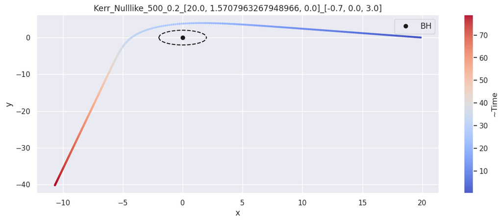

```python
# Definir 4-posición y 4-momentum

q = geod_K.trajectory[1].T[:4]                  # 4-position (cartesian) [Units of GM/c^2]
p = geod_K.trajectory[1].T[-4:]                 # 4 momentum (spherical) [dimensionless]

leap = 1
max_ind = steps-10

# name output
kind = 'Nulllike'       # or Timelike
name = metric +'_'+ kind +'_'+ str(steps) +'_'+ str(delta) +'_'+ str(position) +'_'+ str(momentum)

plotgeod_q(q, leap, max_ind, name, save=False)
```

La gráfica parece bastante estable, lo cual se condice con los warnings que nos dió la simulación (solo 5 al final de la geodésica)

Notar que el punto retorno parece estar desplazado hacia la izquierda respecto a las simulaciones realizadas con agujeros negros estáticos, lo cual se conoce como *frame draggin*, un efecto relativista causado precisamente por la rotación de este agujero negro.

Para visualizar más en profundidad este fenómenos, podemos simular 2 fotones, uno cuya trayectoria siga la rotación del BH y otro que vaya en sentido contrario a esta

```python
# 2 Photons: co-rotating and counter-rotating
# Ya tenemor el primer fotón en geod_K

# Condiciones iniciales
position = [20., np.pi / 2, 0.]             # r, theta, phi (x=20, y=z=0)
momentum = [-.7, 0., -3.]                   # momento inicial hacia abajo izquierda
metric='Kerr'
a = 0.85                                   # Spin = 0 for a Schwarzschild black hole
steps = 500                                # Number of steps to be taken by the solver
delta = 0.2
omega = 0.01
order = 4

# Calcular geodésica
geod_K2 = Nulllike(                    # m=0
    metric=metric,
    metric_params=(a,),
    position=position,
    momentum=momentum,
    steps=steps,
    delta=delta,
    omega=omega,
    order=order,
    suppress_warnings=False,          #True,
    return_cartesian=True          # Obs: Momenta are dimensionless quantities, and are returned in Spherical Polar Coordinates.
)

#print(geod)

# First warning
# Numerical error has exceeded specified tolerance a step = 152. (dang it!)
```

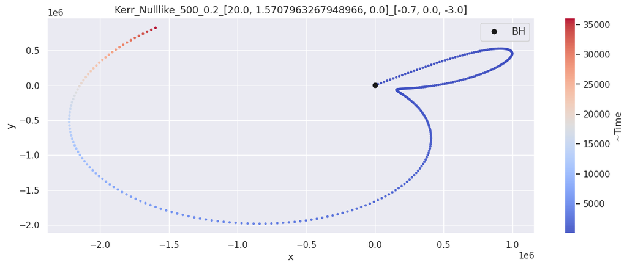

```python
# Definir 4-posición y 4-momentum

q = geod_K2.trajectory[1].T[:4]                  # 4-position (cartesian) [Units of GM/c^2]
p = geod_K2.trajectory[1].T[-4:]                 # 4 momentum (spherical) [dimensionless]

leap = 1
max_ind = steps-10

# name output
kind = 'Nulllike'       # or Timelike
name = metric +'_'+ kind +'_'+ str(steps) +'_'+ str(delta) +'_'+ str(position) +'_'+ str(momentum)

plotgeod_q(q, leap, max_ind, name, save=False)
```

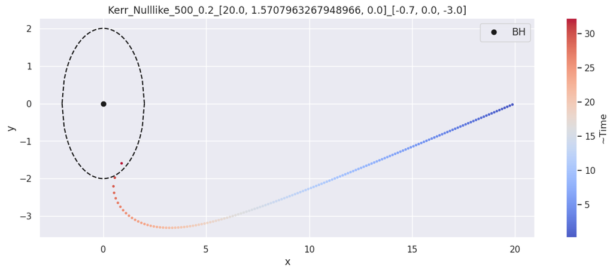

```python
plotgeod_q(q, leap, max_ind=151, name=name, save=False)
```

En este caso, debido a que el fotón viajaba en contra del sentido de rotación del BH, no pudo escapary terminó siendo capturado por el BH de Kerr

```python
'Kerr_ 2_nulllike'[0]=='K'
```

```
True
```

```
1.526782687642637 0.473217312357363
```

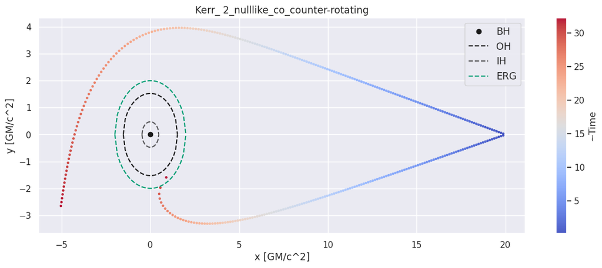

```python
## Plot both photons

plotgeod_q2(q_list=[geod_K.trajectory[1].T[:4], geod_K2.trajectory[1].T[:4]],
             name='Kerr_ 2_nulllike_co_counter-rotating',
             max_ind=[200, 151],
             a=0.85,
             leap=[1,1,1],
             save=True)
```

**Note**: The ergosphere is the region where no observer can remain stationary, due to frame dragging

The ergosphere touches the outer horizon at the poles, but extends out to r=2 at the equator (just like Schild)

Also note that this is just a intuitive representation, these surfaces are not really spherical in the Euclidean sense.

## 3-test-particle simulations: Part I

```python
# Condiciones iniciales
position = [20., np.pi / 2, 0.]                 # r, theta, phi (x=56, y=z=0)
momentum = [-1., 0., 2.7]                       # momento inicial en -r y phi
a = .8                                          # Spin = 0 for a Schwarzschild black hole
steps = [400, 500, 600]                         # Number of steps to be taken by the solver
delta = [1, .5, .2]
omega = [1., 0.1, 0.05]
order = [4, 4, 4]

# Calcular geodésicas
geod_list=[]
for i in range(3):
    geod_A = Nulllike(                    # m=0
        metric="Kerr",
        metric_params=(a,),
        position=position,
        momentum=momentum,
        steps=steps[i],
        delta=delta[i],
        omega=omega[i],
        order=order[i],
        suppress_warnings=False,          #True,
        return_cartesian=True        # Obs: Momenta are dimensionless quantities, and are returned in Spherical Polar Coordinates.
    )
    geod_list.append(geod_A)
    print(f"Sim {i} finished!")

# First warnings
# A: Numerical error has exceeded specified tolerance at step = 20.
# B: None
# C: None
```

Muchas de las simulaciones se caen rápidamente. Realizar las simulaciones de esta manera no es muy conveniente, ya que si se cae una las demás no pueden ejecutarse. Luego, se debe asegurar que la simulación es estable (dadas las condiciones iniciales y los parámetros de la simulación) y luego graficar las 3 juntas.

```
1.5999999999999999 0.40000000000000013
```

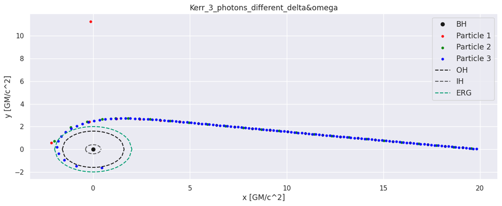

```python
plotgeod_q2(q_list = [geod_list[i].trajectory[1].T[:4] for i in range(3)],
            name='Kerr_3_photons_different_delta&omega',
            max_ind=[23, 44, 116],
            a=.8,
            leap=[1,1,1],
            save=False)
```

```
1.5999999999999999 0.40000000000000013
```

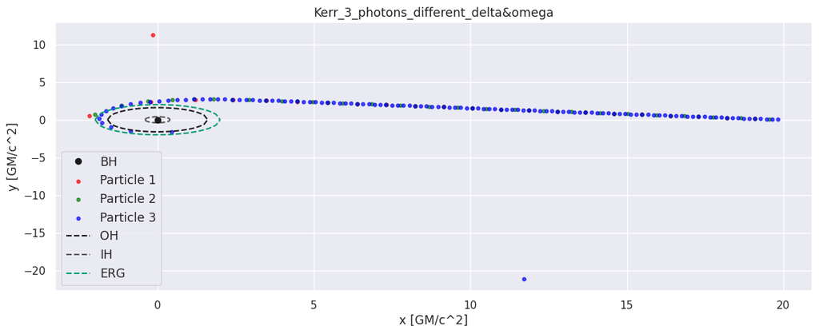

```python
plotgeod_q2(q_list = [geod_list[i].trajectory[1].T[:4] for i in range(3)],
            name='Kerr_3_photons_different_delta&omega',
            max_ind=[23, 44, 117],
            a=.8,
            leap=[1,1,1],
            save=False)
```

Notar que las geodésicas 2 y 3 no dieron wanrings, pero aún así tuvieron grandes problemas en las cercanías del agujero negro.

Se destaca que la partícula 3 pudo pasar de manera estable por la ergoesfera:

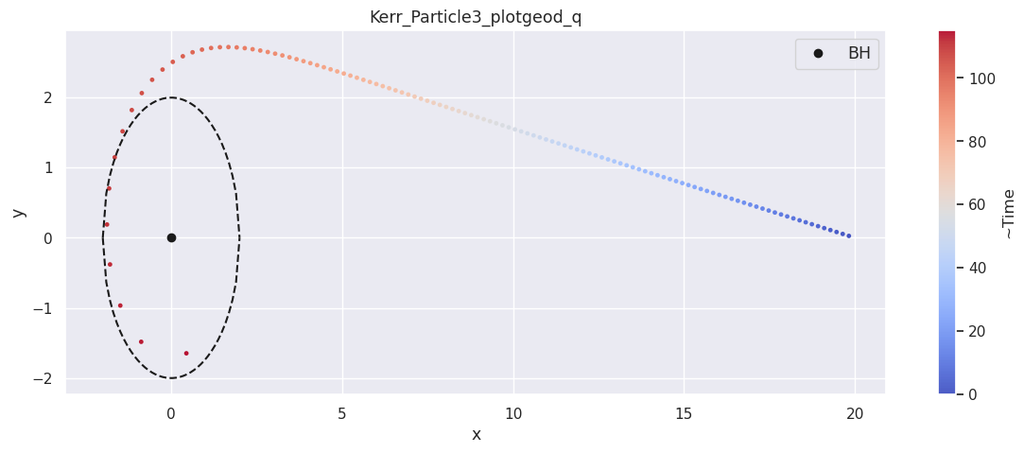

```python
plotgeod_q(geod_list[-1].trajectory[1].T[:4], leap=1, max_ind=116, name='Kerr_Particle3_plotgeod_q', save=False)
```

```
1.5999999999999999 0.40000000000000013
```

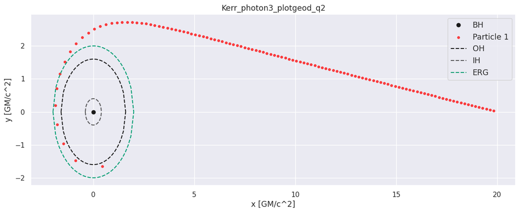

```python
plotgeod_q2(q_list = [geod_list[-1].trajectory[1].T[:4]],
            name='Kerr_photon3_plotgeod_q2',
            max_ind=[116],
            a=.8,
            leap=[1],
            save=False)
```

### Disminuir tolerancia: 1

```python
## Caso 1: counter-rotating
# Condiciones iniciales
position = [20., np.pi / 2, 0.]             # r, theta, phi (x=20, y=z=0)
momentum = [-.6, 0., -3.]                   # momento inicial hacia abajo izquierda
metric='Kerr'
a = 0.8                                   # Spin = 0 for a Schwarzschild black hole
steps = 500                                # Number of steps to be taken by the solver
delta = 0.2
omega = 0.01
order = 4
atol = 1e-5
rtol = 1e-4
```

```python
# Calcular geodésica

geod_B = Nulllike(                    # m=0
    metric=metric,
    metric_params=(a,),
    position=position,
    momentum=momentum,
    steps=steps,
    delta=delta,
    omega=omega,
    order=order,
    atol=atol,
    rtol=rtol,
    suppress_warnings=False,
    return_cartesian=True
)

# Utiliza fantasy por defecto al bajarle las tolerancias
```

[output not shown]

[output cut: 581 more lines]

[output not shown]

```
1.5999999999999999 0.40000000000000013
```

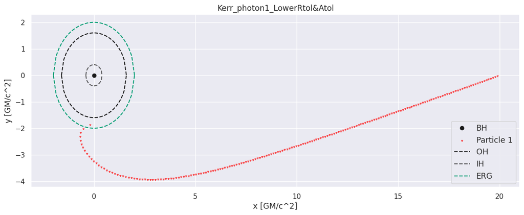

```python
plotgeod_q2([geod_B.trajectory[1].T[:4]],
            name='Kerr_photon1_LowerRtol&Atol',
            max_ind=[185],
            a=.8,
            leap=[1],
            save=False)
```

```python
## Caso 2: co-rotating
# Condiciones iniciales
position = [20., np.pi / 2, 0.]             # r, theta, phi (x=20, y=z=0)
momentum = [-.6, 0., 3.]                   # momento inicial hacia arriba izquierda
metric='Kerr'
a = 0.8                                   # Spin = 0 for a Schwarzschild black hole
steps = 500                                # Number of steps to be taken by the solver
delta = 0.08
omega = 0.01
order = 4
atol = 1e-6
rtol = 1e-5
```

```python
# Calcular geodésica

geod_B = Nulllike(                    # m=0
    metric=metric,
    metric_params=(a,),
    position=position,
    momentum=momentum,
    steps=steps,
    delta=delta,
    omega=omega,
    order=order,
    atol=atol,
    rtol=rtol,
    suppress_warnings=False,
    return_cartesian=True
)

# No warnings!
```

```
1.5999999999999999 0.40000000000000013
```

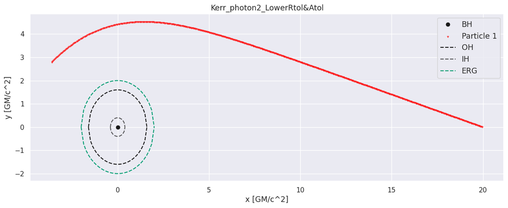

```python
plotgeod_q2([geod_B.trajectory[1].T[:4]],
            name='Kerr_photon2_LowerRtol&Atol',
            max_ind=[500],
            a=.8,
            leap=[1],
            save=False)
```

Dado que disminuimos el `delta`, la simulación fue bastante estable y el integrador tuvo las condiciones necesarias para resolver de manera correcta la geodésica.

One last example...

```python
# 3 posiciones iniciales bastante cercanas, mismo momento inicial
position = [[20., np.pi / 2, -.8*np.pi/4], [20., np.pi / 2, -1.2*np.pi/4], [20., np.pi / 2, -1.6*np.pi/4]]
momentum = [-.6, 0., 3.]                   # momento inicial hacia arriba izquierda
metric='Kerr'
a = 0.8                                    # Spin = 0 for a Schwarzschild black hole
steps = 650                                # Number of steps to be taken by the solver
delta = 0.1
omega = 0.01
order = 4
atol = 1e-4
rtol = 1e-3
```

```python
# 1st geodesic
geod_C1 = Nulllike(                    # m=0
    metric=metric,
    metric_params=(a,),
    position=position[0],
    momentum=momentum,
    steps=steps,
    delta=delta,
    omega=omega,
    order=order,
    atol=atol,
    rtol=rtol,
    suppress_warnings=False,
    return_cartesian=True
)

# No warnings | 2m 6.6s
```

```python
# 2nd geodesic
geod_C2 = Nulllike(                    # m=0
    metric=metric,
    metric_params=(a,),
    position=position[1],
    momentum=momentum,
    steps=steps,
    delta=delta,
    omega=omega,
    order=order,
    atol=atol,
    rtol=rtol,
    suppress_warnings=False,
    return_cartesian=True
)
```

```python
# 3rd geodesic
geod_C3 = Nulllike(                    # m=0
    metric=metric,
    metric_params=(a,),
    position=position[2],
    momentum=momentum,
    steps=steps,
    delta=delta,
    omega=omega,
    order=order,
    atol=atol,
    rtol=rtol,
    suppress_warnings=False,
    return_cartesian=True
)
```

```
1.5999999999999999 0.40000000000000013
```

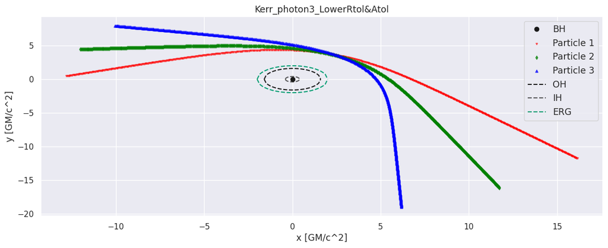

```python
plotgeod_q2(q_list=[geod_C1.trajectory[1].T[:4], geod_C2.trajectory[1].T[:4], geod_C3.trajectory[1].T[:4]],
            name='Kerr_photon3_LowerRtol&Atol',
            max_ind=[600, 600, 600],
            a=.8,
            leap=[1,1,1],
            save=False)
```

```python
def plotgeod_q2_ani(q_list, name, max_ind, a, leap=[1,1,1], save=False):

    # Definir coordenadas
    t_list = [q_list[i][0][:max_ind[i]:leap[i]] for i in range(len(q_list))]
    x_list = [q_list[i][1][:max_ind[i]:leap[i]] for i in range(len(q_list))]
    y_list = [q_list[i][2][:max_ind[i]:leap[i]] for i in range(len(q_list))]
    #cmap_list = ['coolwarm', 'viridis', 'jet']
    color_list = ['red', 'green', 'blue']
    marker_list = ['1', 'd', '^']

    #plt.figure(figsize=(14,5))
    #plt.clf()
    plt.plot(0, 0, "ko", label="BH")                                # point BH
    for i in range(len(q_list)):
        # Geodesics
        plt.scatter(x_list[i], y_list[i], c=color_list[i], marker=marker_list[i],s=12, alpha=.7, label=f'Particle {1+i}')
        #plt.colorbar(label=f"~Time | {i}")     #too messy with 3 colorbars; for absorbed geodesics we can do withouth

    # Event horizon [Update this to support ergosphere and other Kerr BH features]
    ## Schild BH (1 event horizon)
    if name[0]=='S':
        rS = 2.
        xS = np.linspace(-rS,rS,40)
        yS = np.sqrt(rS**2-xS**2)
        plt.plot(xS,yS,'k--',xS,-yS, 'k--')

    ## Kerr BH (2 event horizons + 1 ergosphere)   [Obs: not spherical (Euclidean sense), but S^2 topology]
    elif name[0]=='K':
        r_plus = 1 + np.sqrt(1-a**2)
        r_minus= 1 - np.sqrt(1-a**2)
        xK_p = np.linspace(-r_plus, r_plus, 30)
        yK_p = np.sqrt(r_plus**2 - xK_p**2)
        xK_m = np.linspace(-r_minus, r_minus, 30)
        yK_m = np.sqrt(r_minus**2 - xK_m**2)
        plt.plot(xK_p,yK_p,'k--', label='OH')                 # outer horizon
        plt.plot(xK_p,-yK_p, 'k--')
        plt.plot(xK_m,yK_m,'k--', alpha=.7, label='IH')     # inner horizon
        plt.plot(xK_m,-yK_m, 'k--', alpha=.7,)
        #print(r_plus, r_minus)

        # ergosphere [at the Equator, equal to Schild radius; independent of a]
        rERG = 2.
        xERG = np.linspace(-rERG,rERG,30)
        yERG = np.sqrt(rERG**2-xERG**2)
        plt.plot(xERG,yERG,'g--', label='ERG')      #ergosphere
        plt.plot(xERG,-yERG, 'g--',)

    #if mark:
    #    plt.plot(x[-mark:], y[-mark:], 'k*', markersize=13)
    #plt.colorbar(label="~Time")
    plt.xlabel("x [GM/c^2]", fontsize=12.5)
    plt.ylabel("y [GM/c^2]", fontsize=12.5)
    plt.title(name, fontsize=12.5)
    plt.legend(fontsize=12.5)
    if save==True:
        plt.savefig(name+'.png', dpi=400)
```

```python
#%matplotlib notebook
```

```python
ani.save("my_kerr_animation1.gif", fps=8, writer="pillow");
```

```python
# Exportar imágenes [make gif somewhere else]

n=50
for i in range(1,n+1):
    x = int(i/n * 640)
    plotgeod_q2(q_list=[geod_C1.trajectory[1].T[:4], geod_C2.trajectory[1].T[:4], geod_C3.trajectory[1].T[:4]],
                name=f'Kerr_3photons_ani_{i}',
                max_ind=[x, x, x],
                a=.8,
                leap=[1,1,1],
                save=True)
```

### Disminuir tolerancia: 2

```python
# 3 posiciones iniciales bastante cercanas, mismo momento inicial
position = [[20., np.pi / 2, -.8*np.pi/4], [28., np.pi / 2, -1.2*np.pi/4], [33., np.pi / 2, -1.6*np.pi/4]]
momentum = [[-.9, 0., 3.], [-.6, 0., 3.], [-.3, 0., 3.]]                   # momento inicial hacia arriba izquierda
metric='Kerr'
a = 0.8                                    # Spin = 0 for a Schwarzschild black hole
steps = 650                                # Number of steps to be taken by the solver
delta = 0.1
omega = 0.01
order = 4
atol = 1e-4
rtol = 1e-3
```

```python
# 1st geodesic
geod_C1 = Nulllike(                    # m=0
    metric=metric,
    metric_params=(a,),
    position=position[0],
    momentum=momentum[0],
    steps=steps,
    delta=delta,
    omega=omega,
    order=order,
    atol=atol,
    rtol=rtol,
    suppress_warnings=False,
    return_cartesian=True
)

# No warnings | 1m 54.9s
```

```python
# 2nd geodesic
geod_C2 = Nulllike(                    # m=0
    metric=metric,
    metric_params=(a,),
    position=position[1],
    momentum=momentum[1],
    steps=steps,
    delta=delta,
    omega=omega,
    order=order,
    atol=atol,
    rtol=rtol,
    suppress_warnings=False,
    return_cartesian=True
)

# No Warnings | 1m 9.5s
```

```python
# 3rd geodesic
geod_C3 = Nulllike(                    # m=0
    metric=metric,
    metric_params=(a,),
    position=position[2],
    momentum=momentum[2],
    steps=steps,
    delta=delta,
    omega=omega,
    order=order,
    atol=atol,
    rtol=rtol,
    suppress_warnings=False,
    return_cartesian=True
)

# No Warnings | 1m 54.8s
```

```
1.5999999999999999 0.40000000000000013
```

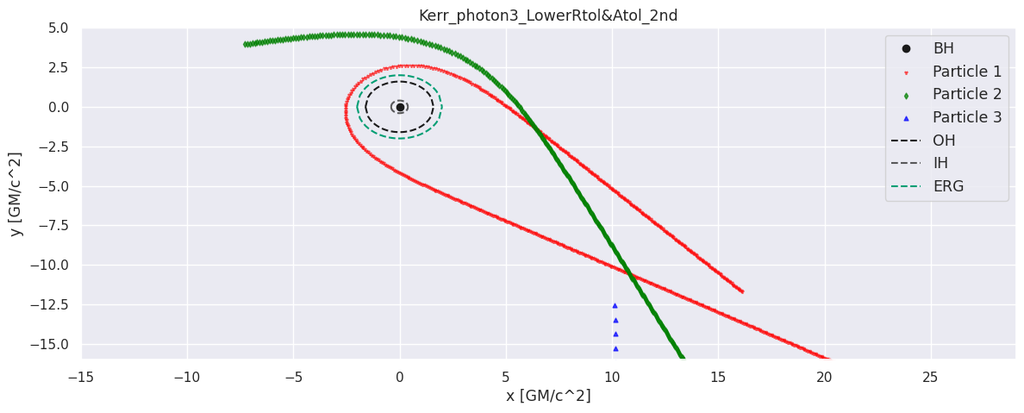

```python
plotgeod_q2(q_list=[geod_C1.trajectory[1].T[:4], geod_C2.trajectory[1].T[:4], geod_C3.trajectory[1].T[:4]],
            name='Kerr_photon3_LowerRtol&Atol_2nd',
            max_ind=[648, 648, 648],
            a=.8,
            leap=[1,2,30],
            save=True,
            lims=[-15, 29, -16, 5])
```

```python
geod_C1.trajectory[1].T[:4][0][-1]          # ~tiempo final
```

```
np.float64(74.64622247950199)
```

```python
geod_C2.trajectory[1].T[:4][0][-1]
```

```
np.float64(47.71590769222416)
```

```python
geod_C3.trajectory[1].T[:4][0][-1]
```

```
np.float64(21.008649890179324)
```

Vemos que las partículas viajan durante intervalos de tiempo diferentes. Los parámetros `steps` y `delta`, no determinan la cantidad de tiempo que va a transcurrir, solamente fijan el valor máximo del parámetro afín y el espaciado sus valores.

Notar que dado que los momenta iniciales son diferentes, también lo serán las energías.

Even if the step size and number of steps are the same, geodesics advance through proper time (or an affine parameter) at different rates depending on their initial 4-velocity (or 4-momentum) and location in spacetime. That means coordinate time t evolves differently for each geodesic

```python
# 3rd geodesic [more steps for the 3rd particle][optionally, we could use delta=1, since this photon is pretty far
#                from the BH]
geod_C3 = Nulllike(                    # m=0
    metric=metric,
    metric_params=(a,),
    position=position[2],
    momentum=momentum[2],
    steps=3*steps,
    delta=delta,
    omega=omega,
    order=order,
    atol=atol,
    rtol=rtol,
    suppress_warnings=False,
    return_cartesian=True
)
```

```python
geod_C3.trajectory[1].T[0][-1]
```

```
np.float64(180.06083193999572)
```

```
1.5999999999999999 0.40000000000000013
```

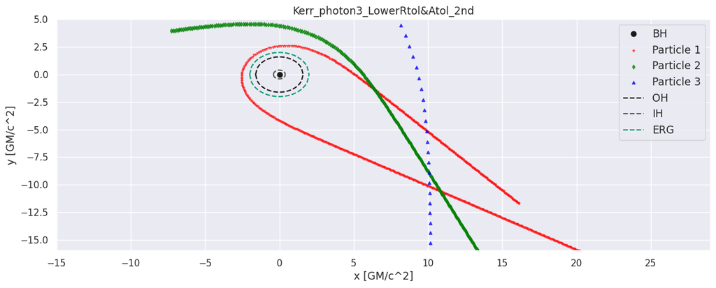

```python
plotgeod_q2(q_list=[geod_C1.trajectory[1].T[:4], geod_C2.trajectory[1].T[:4], geod_C3.trajectory[1].T[:4]],
            name='Kerr_photon3_LowerRtol&Atol_2nd',
            max_ind=[648, 648, 1900],
            a=.8,
            leap=[1,2,30],
            save=True,
            lims=[-15, 29, -16, 5])
```